# NYC_Crime_Data_V2

J. Luciano

2022-04-17

## NYC Crime Data

The report contains data from the following website: https://data.cityofnewyork.us.

Overall goal was to identify if there is a high correlation between the amount of arrests and shootings.

I have downloaded a CSV file of Arrest Data and Shooting Data.

I have analyzed the amount of shooting by Borough (Boro) and Precinct.

I have also included a linear model with shooting being the target value and it being based on the the number of arrests.

Note - I have summed all historic data.

Libraries uses

```r
library(RCurl)
library(tidyverse)
library(dplyr)
```

Reading in the data from 2 csv files NYC Shooting Data and NYC Arrest Data

```r
NYC_Shooting_data <- read_csv("https://data.cityofnewyork.us/api/views/833y-fsy8/rows.csv?accessType=DOWNLOAD")
NYC_Arrest_Data <- read.csv("https://data.cityofnewyork.us/api/views/8h9b-rp9u/rows.csv?accessType=DOWNLOAD", header=TRUE)
```

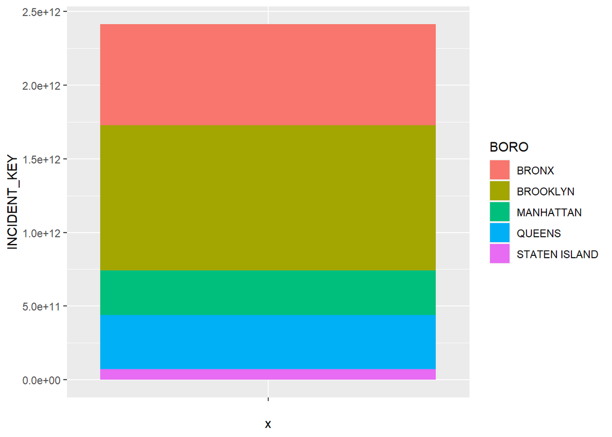

```r
NYC_BP <- ggplot(NYC_Shooting_data, aes(x="", y = INCIDENT_KEY ,fill=BORO))+
geom_bar(width = 1, stat = "identity")
NYC_BP
```

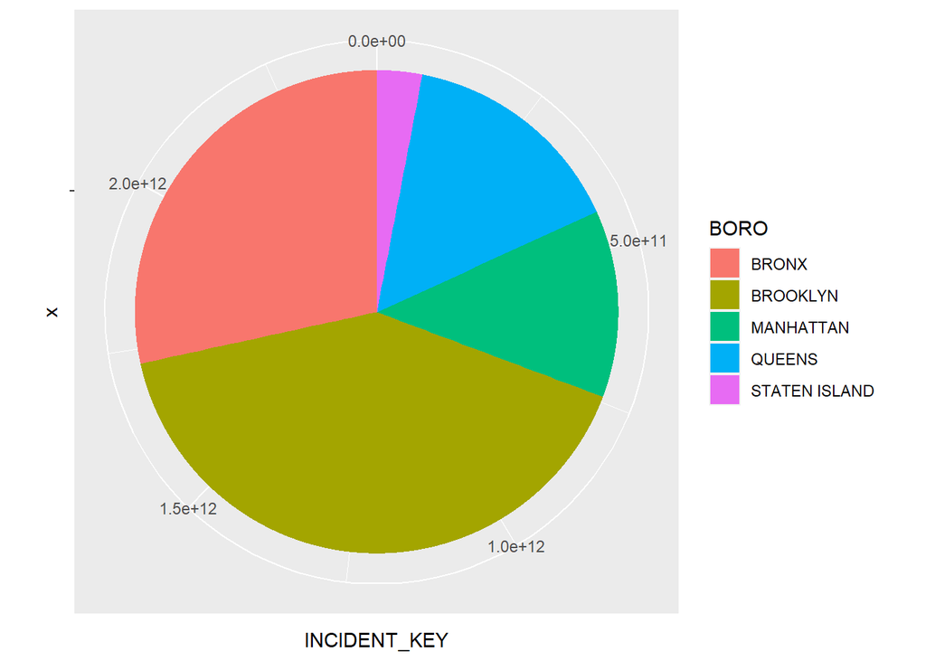

```r
NYC_Pie <- NYC_BP + coord_polar("y",start=0)

NYC_Pie
```

Creating a count of shooting, group by data is based on Precinct Data is shown

```r
NYC_Shooting_BY_PRECINCT <- NYC_Shooting_data %>% group_by(PRECINCT) %>% tally()
NYC_Shooting_BY_PRECINCT  <- NYC_Shooting_BY_PRECINCT  %>%
rename(Number_Of_Shootings  = n)
NYC_Shooting_BY_PRECINCT
```

```
## # A tibble: 77 x 2
##    PRECINCT Number_Of_Shootings
##       <dbl>               <int>
##  1        1                  22
##  2        5                  48
##  3        6                  24
##  4        7                  86
##  5        9                  94
##  6       10                  58
##  7       13                  52
##  8       14                  30
##  9       17                   6
## 10       18                  26
## # ... with 67 more rows
```

count of arrest by precicint we also changed the name of arrest_precinct columnt to precinct data is shown

```r
NYC_Arrest_BY_PRECINCTS <- NYC_Arrest_Data %>% group_by(ARREST_PRECINCT) %>% tally()

NYC_Arrest_BY_PRECINCTS  <- NYC_Arrest_BY_PRECINCTS  %>%
rename(PRECINCT  = ARREST_PRECINCT)

NYC_Arrest_BY_PRECINCTS  <- NYC_Arrest_BY_PRECINCTS  %>%
rename(Number_Of_Arrests  = n)
NYC_Arrest_BY_PRECINCTS
```

```
## # A tibble: 78 x 2
##    PRECINCT Number_Of_Arrests
##       <int>             <int>
##  1        1             62532
##  2        5             77949
##  3        6             56461
##  4        7             46657
##  5        9             54005
##  6       10             43448
##  7       13             67019
##  8       14            179971
##  9       17             26192
## 10       18             71902
## # ... with 68 more rows
```

Merge NYC_Shooting_BY_PRECINCT and NYC_Arrest_By_Precinct data frames (join them together) Data is shown

```r
NYC_Combined_Crime_Data = merge(x=NYC_Arrest_BY_PRECINCTS ,y=NYC_Shooting_BY_PRECINCT  ,by="PRECINCT",all.y=TRUE)
NYC_Combined_Crime_Data
```

```
##    PRECINCT Number_Of_Arrests Number_Of_Shootings
## 1         1             62532                  22
## 2         5             77949                  48
## 3         6             56461                  24
## 4         7             46657                  86
## 5         9             54005                  94
## 6        10             43448                  58
## 7        13             67019                  52
## 8        14            179971                  30
## 9        17             26192                   6
## 10       18             71902                  26
## 11       19             44955                  11
## 12       20             29680                  32
## 13       22              6584                   1
## 14       23             76108                 418
```

[output cut: 63 more lines]

Building Predictive Linear Model with NYC_Combined_Data Will look to predict the amount shootings based on how many arrests are made

```r
mod <- lm(Number_Of_Shootings ~ Number_Of_Arrests , data = NYC_Combined_Crime_Data)
summary(mod)
```

```
##
## Call:
## lm(formula = Number_Of_Shootings ~ Number_Of_Arrests, data = NYC_Combined_Crime_Data)
##
## Residuals:
##     Min      1Q  Median      3Q     Max
## -955.56 -107.22  -24.51   83.63  648.45
##
## Coefficients:
##                     Estimate Std. Error t value Pr(>|t|)
## (Intercept)       -9.585e+01  5.329e+01  -1.799   0.0761 .
## Number_Of_Arrests  6.009e-03  6.975e-04   8.615 8.06e-13 ***
## ---
## Signif. codes:  0 '***' 0.001 '**' 0.01 '*' 0.05 '.' 0.1 ' ' 1
##
## Residual standard error: 225.5 on 75 degrees of freedom
## Multiple R-squared:  0.4974, Adjusted R-squared:  0.4906
## F-statistic: 74.21 on 1 and 75 DF,  p-value: 8.063e-13
```

Building LInear Graphs that first plot number of arrests compared to shooting Then we add the linear model in with a red line.

```r
shootings.graph<-ggplot(NYC_Combined_Crime_Data, aes(x=Number_Of_Arrests, y=Number_Of_Shootings))+ geom_point()
```

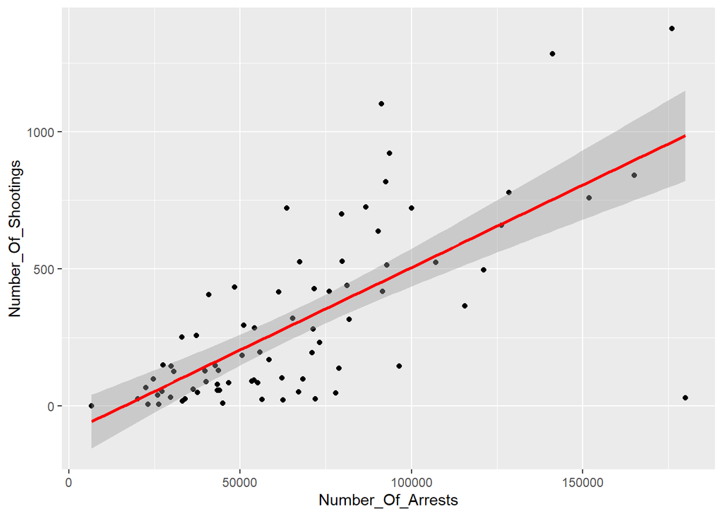

```r
shootings.graph <- shootings.graph + geom_smooth(method="lm", col="red")
shootings.graph
```

Closing wording, I did have a bias, as I would have assumed that the there would be a high correlation of shootings where a high number of arrests were made.

Also, my assumption is that in Staten Island which has a more suburban feel, there would be less shootings per arrest.

Based on the data there is a high correlation when comparing arrests to shootings in each precinct.

Ultimately, there is a probably high causation based on weatlth, population density, access to education and other factors that would need to be included in the analysis.

Higher crimes in itself will lead to more arrests and shootings, thus, the correlation makes sense.

sessionInfo()